# Survey Dashboard

2024 IOM South Sudan

Data & Methods Subteam - Bass Connections

2024-09-29

```r
#install packages

install.packages("sjmisc")
install.packages("likert")
```

All question numbers below are based on the “Key Variables for Descriptive Statistics” doc file.

All the descriptives calculated for index questions were based on the **unimputed** variable.

```
## [1] "Q9.8.1"  "Q9.8.10" "Q9.8.11" "Q9.8.12"
```

```
## # A tibble: 2 × 2
##   Q2.1   count
##   <chr>  <int>
## 1 Female  2261
## 2 Male    1424
```

# 1) Political and Legal Fragility

The higher, the more fragile.

## Index Questions

### Q10.1.2: How much confidence do you have in your state government?

0 - A lot of confidence

0.33 - Confidence

0.67 - Some Confidence

1 - No Confidence

#### Entire sample

| mean |
| --- |
| 0.51 |

| Response | Number of Responses | Percent of Total Responses |
| --- | --- | --- |
| Some confidence | 1440 | 0.39 |
| Confidence | 1323 | 0.36 |
| No confidence | 489 | 0.13 |
| A lot of confidence | 426 | 0.12 |
| Prefer not to answer | 7 | 0.00 |

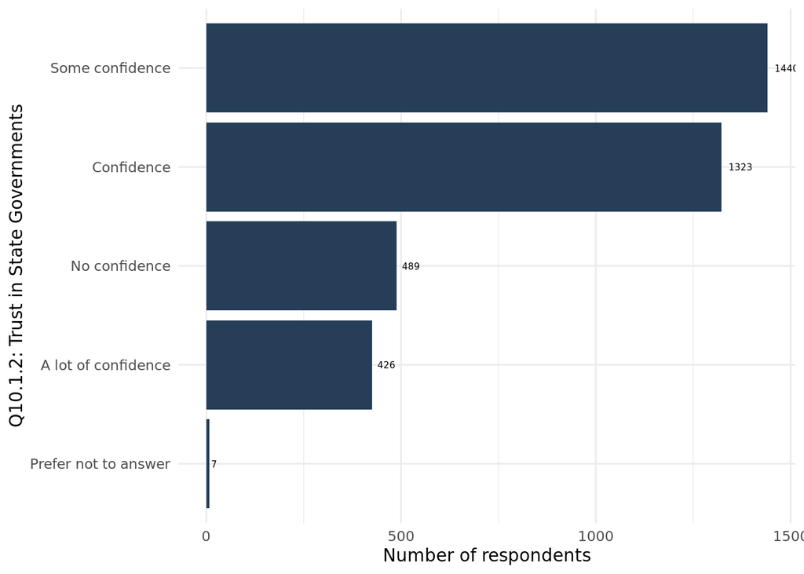

#### By county

| County | Mean Response (0 to 1) |
| --- | --- |
| Bor South | 0.65 |
| Yei | 0.63 |
| Lainya | 0.57 |
| Malakal | 0.55 |
| Rubkona | 0.53 |
| Morobo | 0.49 |
| Wau | 0.46 |
| Pibor | 0.40 |
| Kajo-keji | 0.32 |

| County | Response | Number of Responses | Percent of Total Responses in the County |
| --- | --- | --- | --- |
| Yei | A lot of confidence | 15 | 0.04 |
| Yei | Confidence | 113 | 0.28 |
| Yei | No confidence | 93 | 0.23 |
| Yei | Some confidence | 189 | 0.46 |
| Wau | A lot of confidence | 48 | 0.12 |
| Wau | Confidence | 184 | 0.46 |
| Wau | No confidence | 28 | 0.07 |
| Wau | Prefer not to answer | 3 | 0.01 |
| Wau | Some confidence | 139 | 0.35 |
| Rubkona | A lot of confidence | 32 | 0.08 |
| Rubkona | Confidence | 117 | 0.29 |
| Rubkona | No confidence | 19 | 0.05 |
| Rubkona | Some confidence | 232 | 0.58 |
| Pibor | A lot of confidence | 82 | 0.20 |
| Pibor | Confidence | 193 | 0.47 |
| Pibor | No confidence | 36 | 0.09 |
| Pibor | Some confidence | 96 | 0.24 |
| Morobo | A lot of confidence | 72 | 0.18 |
| Morobo | Confidence | 128 | 0.32 |
| Morobo | No confidence | 64 | 0.16 |
| Morobo | Prefer not to answer | 1 | 0.00 |
| Morobo | Some confidence | 139 | 0.34 |
| Malakal | A lot of confidence | 5 | 0.01 |
| Malakal | Confidence | 168 | 0.40 |
| Malakal | No confidence | 33 | 0.08 |
| Malakal | Some confidence | 215 | 0.51 |
| Lainya | A lot of confidence | 23 | 0.06 |
| Lainya | Confidence | 136 | 0.33 |
| Lainya | No confidence | 60 | 0.14 |
| Lainya | Prefer not to answer | 2 | 0.00 |
| Lainya | Some confidence | 193 | 0.47 |
| Kajo-keji | A lot of confidence | 130 | 0.33 |
| Kajo-keji | Confidence | 169 | 0.42 |
| Kajo-keji | No confidence | 23 | 0.06 |
| Kajo-keji | Prefer not to answer | 1 | 0.00 |
| Kajo-keji | Some confidence | 75 | 0.19 |
| Bor South | A lot of confidence | 19 | 0.04 |
| Bor South | Confidence | 115 | 0.27 |
| Bor South | No confidence | 133 | 0.31 |
| Bor South | Some confidence | 162 | 0.38 |

### Q10.1.10: How much confidence do you have in informal authorities, such as councils of elders?

0 - A lot of confidence

0.33 - Confidence

0.67 - Some Confidence

1 - No Confidence

#### Entire sample

| mean |
| --- |
| 0.45 |

| Response | Number of Responses | Percent of Total Responses |
| --- | --- | --- |
| Confidence | 1524 | 0.41 |
| Some confidence | 1215 | 0.33 |
| A lot of confidence | 605 | 0.16 |
| No confidence | 316 | 0.09 |
| Prefer not to answer | 25 | 0.01 |

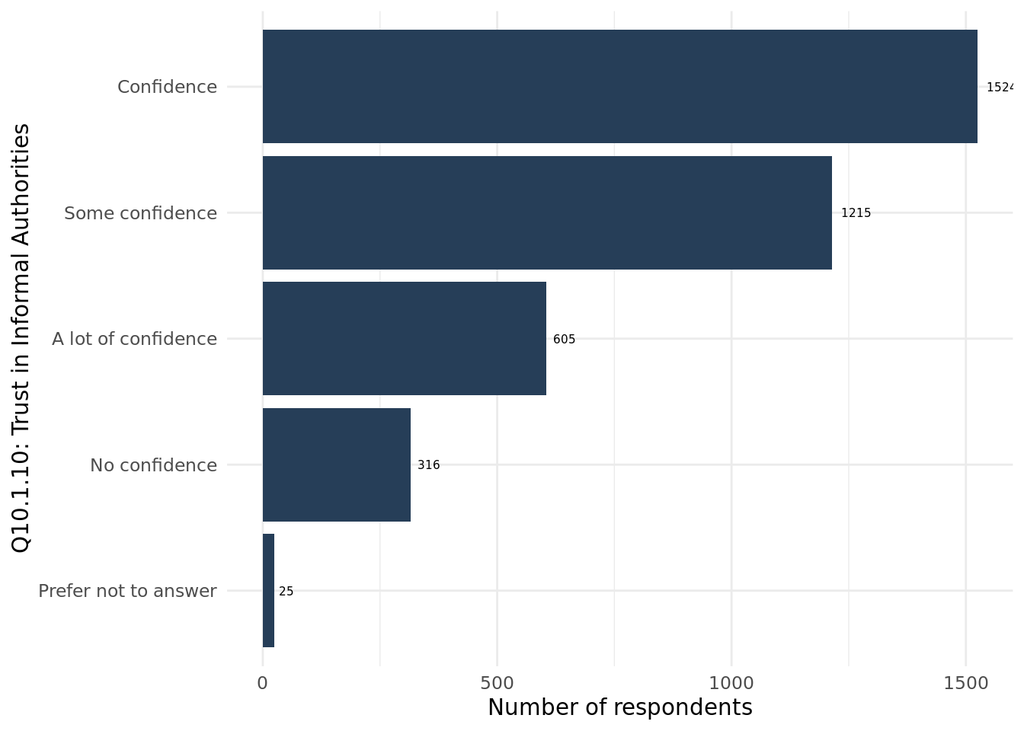

#### By county

| County | Mean Response (0 to 1) |
| --- | --- |
| Yei | 0.56 |
| Rubkona | 0.50 |
| Pibor | 0.49 |
| Wau | 0.46 |
| Malakal | 0.45 |
| Lainya | 0.45 |
| Morobo | 0.41 |
| Kajo-keji | 0.36 |
| Bor South | 0.34 |

| County | Response | Number of Responses | Percent of Total Responses in the county |
| --- | --- | --- | --- |
| Yei | A lot of confidence | 23 | 0.06 |
| Yei | Confidence | 139 | 0.34 |
| Yei | No confidence | 55 | 0.13 |
| Yei | Some confidence | 193 | 0.47 |
| Wau | A lot of confidence | 57 | 0.14 |
| Wau | Confidence | 150 | 0.37 |
| Wau | No confidence | 16 | 0.04 |
| Wau | Prefer not to answer | 9 | 0.02 |
| Wau | Some confidence | 170 | 0.42 |
| Rubkona | A lot of confidence | 34 | 0.09 |
| Rubkona | Confidence | 139 | 0.35 |
| Rubkona | No confidence | 6 | 0.01 |
| Rubkona | Prefer not to answer | 1 | 0.00 |
| Rubkona | Some confidence | 220 | 0.55 |
| Pibor | A lot of confidence | 52 | 0.13 |
| Pibor | Confidence | 182 | 0.45 |
| Pibor | No confidence | 73 | 0.18 |
| Pibor | Prefer not to answer | 1 | 0.00 |
| Pibor | Some confidence | 99 | 0.24 |
| Morobo | A lot of confidence | 74 | 0.18 |
| Morobo | Confidence | 194 | 0.48 |
| Morobo | No confidence | 35 | 0.09 |
| Morobo | Prefer not to answer | 2 | 0.00 |
| Morobo | Some confidence | 99 | 0.25 |
| Malakal | A lot of confidence | 16 | 0.04 |
| Malakal | Confidence | 250 | 0.59 |
| Malakal | No confidence | 6 | 0.01 |
| Malakal | Some confidence | 149 | 0.35 |
| Lainya | A lot of confidence | 91 | 0.22 |
| Lainya | Confidence | 145 | 0.35 |
| Lainya | No confidence | 57 | 0.14 |
| Lainya | Prefer not to answer | 5 | 0.01 |
| Lainya | Some confidence | 116 | 0.28 |
| Kajo-keji | A lot of confidence | 94 | 0.24 |
| Kajo-keji | Confidence | 188 | 0.47 |
| Kajo-keji | No confidence | 19 | 0.05 |
| Kajo-keji | Prefer not to answer | 7 | 0.02 |
| Kajo-keji | Some confidence | 90 | 0.23 |
| Bor South | A lot of confidence | 164 | 0.38 |
| Bor South | Confidence | 137 | 0.32 |
| Bor South | No confidence | 49 | 0.11 |
| Bor South | Some confidence | 79 | 0.18 |

### Q10.10: South Sudan’s next national elections are scheduled for December 2024 after being postponed several times. How safe or unsafe would you feel going to a polling station to cast your vote?

0 very safe

0.25 somewhat safe

0.5 neither safe nor unsafe

0.75 somewhat unsafe

1 very unsafe

#### Entire sample

| mean |
| --- |
| 0.5 |

| Response | Number of Responses | Percent of Total Responses |
| --- | --- | --- |
| Very unsafe | 820 | 0.22 |
| Very safe | 802 | 0.22 |
| Somewhat safe | 695 | 0.19 |
| Neither safe nor unsafe | 677 | 0.18 |
| Somewhat unsafe | 621 | 0.17 |
| Prefer not to answer | 70 | 0.02 |

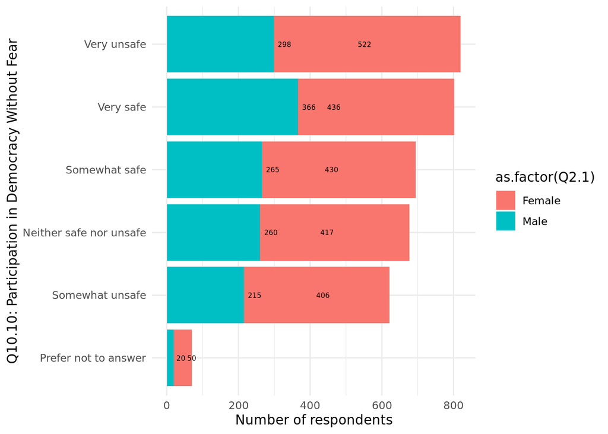

#### By county

| County | Mean Response (0 to 1) |
| --- | --- |
| Rubkona | 0.68 |
| Pibor | 0.60 |
| Bor South | 0.58 |
| Malakal | 0.55 |
| Lainya | 0.52 |
| Kajo-keji | 0.43 |
| Yei | 0.41 |
| Wau | 0.40 |
| Morobo | 0.29 |

| County | Response | Number of Responses | Percent of Total Responses in the county |
| --- | --- | --- | --- |
| Yei | Neither safe nor unsafe | 89 | 0.22 |
| Yei | Prefer not to answer | 3 | 0.01 |
| Yei | Somewhat safe | 132 | 0.32 |
| Yei | Somewhat unsafe | 66 | 0.16 |
| Yei | Very safe | 81 | 0.20 |
| Yei | Very unsafe | 39 | 0.10 |
| Wau | Neither safe nor unsafe | 105 | 0.26 |
| Wau | Prefer not to answer | 38 | 0.09 |
| Wau | Somewhat safe | 107 | 0.27 |
| Wau | Somewhat unsafe | 57 | 0.14 |
| Wau | Very safe | 73 | 0.18 |
| Wau | Very unsafe | 22 | 0.05 |
| Rubkona | Neither safe nor unsafe | 48 | 0.12 |
| Rubkona | Prefer not to answer | 4 | 0.01 |
| Rubkona | Somewhat safe | 56 | 0.14 |
| Rubkona | Somewhat unsafe | 84 | 0.21 |
| Rubkona | Very safe | 38 | 0.10 |
| Rubkona | Very unsafe | 170 | 0.42 |
| Pibor | Neither safe nor unsafe | 85 | 0.21 |
| Pibor | Prefer not to answer | 6 | 0.01 |
| Pibor | Somewhat safe | 60 | 0.15 |
| Pibor | Somewhat unsafe | 137 | 0.34 |
| Pibor | Very safe | 40 | 0.10 |
| Pibor | Very unsafe | 79 | 0.19 |
| Morobo | Neither safe nor unsafe | 43 | 0.11 |
| Morobo | Somewhat safe | 52 | 0.13 |
| Morobo | Somewhat unsafe | 42 | 0.10 |
| Morobo | Very safe | 215 | 0.53 |
| Morobo | Very unsafe | 52 | 0.13 |
| Malakal | Neither safe nor unsafe | 75 | 0.18 |
| Malakal | Prefer not to answer | 2 | 0.00 |
| Malakal | Somewhat safe | 150 | 0.36 |
| Malakal | Somewhat unsafe | 69 | 0.16 |
| Malakal | Very safe | 21 | 0.05 |
| Malakal | Very unsafe | 104 | 0.25 |
| Lainya | Neither safe nor unsafe | 88 | 0.21 |
| Lainya | Prefer not to answer | 8 | 0.02 |
| Lainya | Somewhat safe | 43 | 0.10 |
| Lainya | Somewhat unsafe | 50 | 0.12 |
| Lainya | Very safe | 105 | 0.25 |
| Lainya | Very unsafe | 120 | 0.29 |
| Kajo-keji | Neither safe nor unsafe | 48 | 0.12 |
| Kajo-keji | Prefer not to answer | 5 | 0.01 |
| Kajo-keji | Somewhat safe | 66 | 0.17 |
| Kajo-keji | Somewhat unsafe | 45 | 0.11 |
| Kajo-keji | Very safe | 140 | 0.35 |
| Kajo-keji | Very unsafe | 94 | 0.24 |
| Bor South | Neither safe nor unsafe | 96 | 0.22 |
| Bor South | Prefer not to answer | 4 | 0.01 |
| Bor South | Somewhat safe | 29 | 0.07 |
| Bor South | Somewhat unsafe | 71 | 0.17 |
| Bor South | Very safe | 89 | 0.21 |
| Bor South | Very unsafe | 140 | 0.33 |

### Q10.12: At present, how safe do you feel speaking publicly on politically sensitive issues?

0 - very safe

0.25 - safe

0.5 - neither safe nor unsafe

0.75 - unsafe

1 - very unsafe

#### Entire sample

| mean |
| --- |
| 0.6 |

| Response | Number of Responses | Percent of Total Responses |
| --- | --- | --- |
| Unsafe | 1093 | 0.30 |
| Very unsafe | 833 | 0.23 |
| Safe | 810 | 0.22 |
| Neither safe nor unsafe | 641 | 0.17 |
| Very safe | 238 | 0.06 |
| Prefer not to answer | 70 | 0.02 |

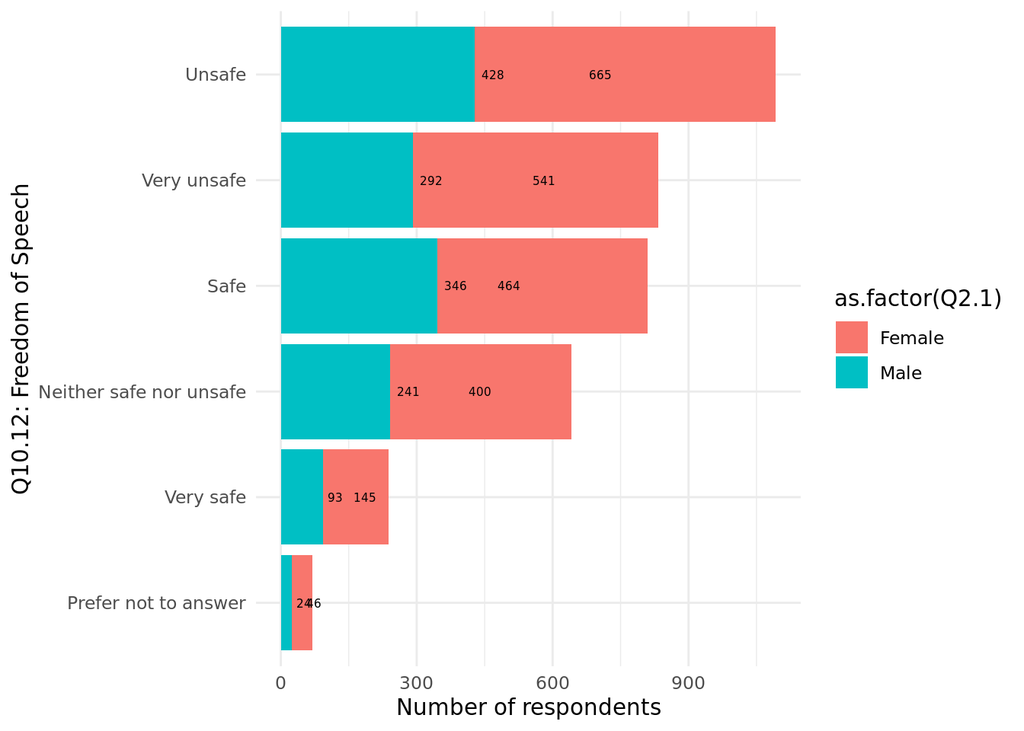

#### By county

| County | Mean Response (0 to 1) |
| --- | --- |
| Rubkona | 0.71 |
| Bor South | 0.69 |
| Kajo-keji | 0.65 |
| Malakal | 0.61 |
| Wau | 0.57 |
| Lainya | 0.57 |
| Morobo | 0.56 |
| Pibor | 0.54 |
| Yei | 0.53 |

| County | Response | Number of Responses | Percent of Total Responses in the county |
| --- | --- | --- | --- |
| Yei | Neither safe nor unsafe | 103 | 0.25 |
| Yei | Prefer not to answer | 5 | 0.01 |
| Yei | Safe | 117 | 0.29 |
| Yei | Unsafe | 151 | 0.37 |
| Yei | Very safe | 12 | 0.03 |
| Yei | Very unsafe | 22 | 0.05 |
| Wau | Neither safe nor unsafe | 78 | 0.19 |
| Wau | Prefer not to answer | 44 | 0.11 |
| Wau | Safe | 79 | 0.20 |
| Wau | Unsafe | 139 | 0.35 |
| Wau | Very safe | 22 | 0.05 |
| Wau | Very unsafe | 40 | 0.10 |
| Rubkona | Neither safe nor unsafe | 40 | 0.10 |
| Rubkona | Prefer not to answer | 2 | 0.00 |
| Rubkona | Safe | 56 | 0.14 |
| Rubkona | Unsafe | 89 | 0.22 |
| Rubkona | Very safe | 33 | 0.08 |
| Rubkona | Very unsafe | 180 | 0.45 |
| Pibor | Neither safe nor unsafe | 110 | 0.27 |
| Pibor | Prefer not to answer | 7 | 0.02 |
| Pibor | Safe | 115 | 0.28 |
| Pibor | Unsafe | 140 | 0.34 |
| Pibor | Very safe | 8 | 0.02 |
| Pibor | Very unsafe | 27 | 0.07 |
| Morobo | Neither safe nor unsafe | 40 | 0.10 |
| Morobo | Prefer not to answer | 1 | 0.00 |
| Morobo | Safe | 127 | 0.31 |
| Morobo | Unsafe | 75 | 0.19 |
| Morobo | Very safe | 45 | 0.11 |
| Morobo | Very unsafe | 116 | 0.29 |
| Malakal | Neither safe nor unsafe | 73 | 0.17 |
| Malakal | Safe | 103 | 0.24 |
| Malakal | Unsafe | 175 | 0.42 |
| Malakal | Very safe | 8 | 0.02 |
| Malakal | Very unsafe | 62 | 0.15 |
| Lainya | Neither safe nor unsafe | 87 | 0.21 |
| Lainya | Prefer not to answer | 4 | 0.01 |
| Lainya | Safe | 89 | 0.21 |
| Lainya | Unsafe | 123 | 0.30 |
| Lainya | Very safe | 37 | 0.09 |
| Lainya | Very unsafe | 74 | 0.18 |
| Kajo-keji | Neither safe nor unsafe | 45 | 0.11 |
| Kajo-keji | Prefer not to answer | 5 | 0.01 |
| Kajo-keji | Safe | 69 | 0.17 |
| Kajo-keji | Unsafe | 61 | 0.15 |
| Kajo-keji | Very safe | 49 | 0.12 |
| Kajo-keji | Very unsafe | 169 | 0.42 |
| Bor South | Neither safe nor unsafe | 65 | 0.15 |
| Bor South | Prefer not to answer | 2 | 0.00 |
| Bor South | Safe | 55 | 0.13 |
| Bor South | Unsafe | 140 | 0.33 |
| Bor South | Very safe | 24 | 0.06 |
| Bor South | Very unsafe | 143 | 0.33 |

### Q10.13: Which of the following statements best describes the role that politicians in Juba play in your community?

0 - make community much more safe

0.25 - make community more safe

0.5 - make community neither more nor less safe

0.75 - make community less safe

1 - make community much less safe

#### Entire sample

| mean |
| --- |
| 0.67 |

| Response | Number of Responses | Percent of Total Responses in the county |
| --- | --- | --- |
| Politicians in Juba make this community much less safe | 1043 | 0.28 |
| Politicians in Juba make this community less safe | 943 | 0.26 |
| Politicians in Juba neither make this community more nor less safe | 867 | 0.24 |
| Politicians in Juba make this community more safe | 404 | 0.11 |
| Prefer not to answer | 283 | 0.08 |
| Politicians in Juba make this community much more safe | 145 | 0.04 |

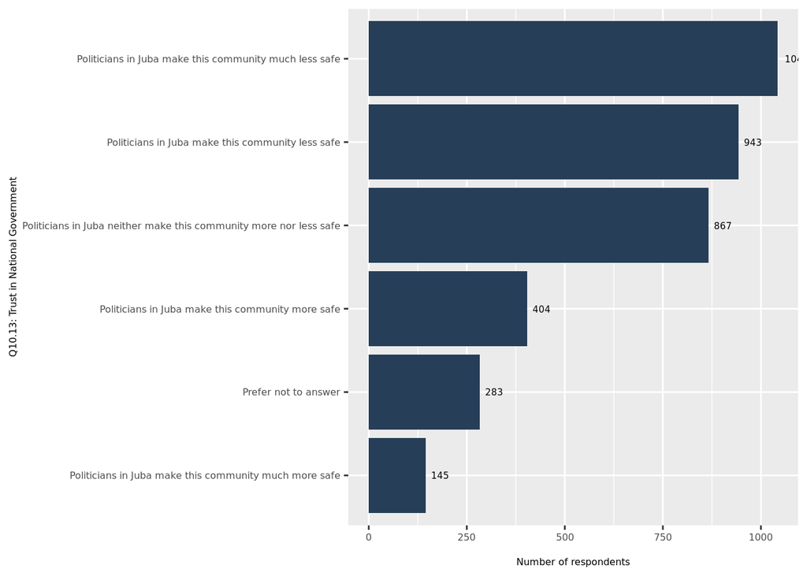

#### By county

| County | Mean Response (0 to 1) |
| --- | --- |
| Bor South | 0.76 |
| Rubkona | 0.76 |
| Yei | 0.75 |
| Malakal | 0.74 |
| Pibor | 0.67 |
| Morobo | 0.61 |
| Lainya | 0.58 |
| Kajo-keji | 0.56 |
| Wau | 0.54 |

| County | Response | Number of Responses | Percent of Total Responses |
| --- | --- | --- | --- |
| Yei | Politicians in Juba make this community less safe | 151 | 0.37 |
| Yei | Politicians in Juba make this community more safe | 23 | 0.06 |
| Yei | Politicians in Juba make this community much less safe | 145 | 0.35 |
| Yei | Politicians in Juba make this community much more safe | 7 | 0.02 |
| Yei | Politicians in Juba neither make this community more nor less safe | 78 | 0.19 |
| Yei | Prefer not to answer | 6 | 0.01 |
| Wau | Politicians in Juba make this community less safe | 65 | 0.16 |
| Wau | Politicians in Juba make this community more safe | 43 | 0.11 |
| Wau | Politicians in Juba make this community much less safe | 35 | 0.09 |
| Wau | Politicians in Juba make this community much more safe | 28 | 0.07 |
| Wau | Politicians in Juba neither make this community more nor less safe | 70 | 0.17 |
| Wau | Prefer not to answer | 161 | 0.40 |
| Rubkona | Politicians in Juba make this community less safe | 83 | 0.21 |
| Rubkona | Politicians in Juba make this community more safe | 26 | 0.06 |
| Rubkona | Politicians in Juba make this community much less safe | 182 | 0.46 |
| Rubkona | Politicians in Juba make this community much more safe | 4 | 0.01 |
| Rubkona | Politicians in Juba neither make this community more nor less safe | 100 | 0.25 |
| Rubkona | Prefer not to answer | 5 | 0.01 |
| Pibor | Politicians in Juba make this community less safe | 111 | 0.27 |
| Pibor | Politicians in Juba make this community more safe | 54 | 0.13 |
| Pibor | Politicians in Juba make this community much less safe | 126 | 0.31 |
| Pibor | Politicians in Juba make this community much more safe | 17 | 0.04 |
| Pibor | Politicians in Juba neither make this community more nor less safe | 91 | 0.22 |
| Pibor | Prefer not to answer | 8 | 0.02 |
| Morobo | Politicians in Juba make this community less safe | 93 | 0.23 |
| Morobo | Politicians in Juba make this community more safe | 55 | 0.14 |
| Morobo | Politicians in Juba make this community much less safe | 113 | 0.28 |
| Morobo | Politicians in Juba make this community much more safe | 46 | 0.11 |
| Morobo | Politicians in Juba neither make this community more nor less safe | 96 | 0.24 |
| Morobo | Prefer not to answer | 1 | 0.00 |
| Malakal | Politicians in Juba make this community less safe | 197 | 0.47 |
| Malakal | Politicians in Juba make this community more safe | 20 | 0.05 |
| Malakal | Politicians in Juba make this community much less safe | 117 | 0.28 |
| Malakal | Politicians in Juba neither make this community more nor less safe | 87 | 0.21 |
| Lainya | Politicians in Juba make this community less safe | 97 | 0.23 |
| Lainya | Politicians in Juba make this community more safe | 56 | 0.14 |
| Lainya | Politicians in Juba make this community much less safe | 68 | 0.16 |
| Lainya | Politicians in Juba make this community much more safe | 23 | 0.06 |
| Lainya | Politicians in Juba neither make this community more nor less safe | 155 | 0.37 |
| Lainya | Prefer not to answer | 15 | 0.04 |
| Kajo-keji | Politicians in Juba make this community less safe | 65 | 0.16 |
| Kajo-keji | Politicians in Juba make this community more safe | 110 | 0.28 |
| Kajo-keji | Politicians in Juba make this community much less safe | 83 | 0.21 |
| Kajo-keji | Politicians in Juba make this community much more safe | 14 | 0.04 |
| Kajo-keji | Politicians in Juba neither make this community more nor less safe | 89 | 0.22 |
| Kajo-keji | Prefer not to answer | 37 | 0.09 |
| Bor South | Politicians in Juba make this community less safe | 81 | 0.19 |
| Bor South | Politicians in Juba make this community more safe | 17 | 0.04 |
| Bor South | Politicians in Juba make this community much less safe | 174 | 0.41 |
| Bor South | Politicians in Juba make this community much more safe | 6 | 0.01 |
| Bor South | Politicians in Juba neither make this community more nor less safe | 101 | 0.24 |
| Bor South | Prefer not to answer | 50 | 0.12 |

# Additional Political/Legal Descriptive Questions

### Q9.8 **How much do you think the following policies would contribute to long-term peace in South Sudan, on a scale from 1 through 5 where 1 means “makes peace much less likely” and 5 means “makes peace much more likely.”**

Makes peace much less likely  
Makes peace less likely  
Has no effect on peace  
Makes peace more likely  
Makes peace much more likely  
Prefer not to answer

### **Q9.8.1 Dialogues between community members**

#### Entire sample

| mean |
| --- |
| NA |

| Most Common Response | Number of Responses | Percent of Total Responses |
| --- | --- | --- |
| Makes peace more likely | 1850 | 100 |

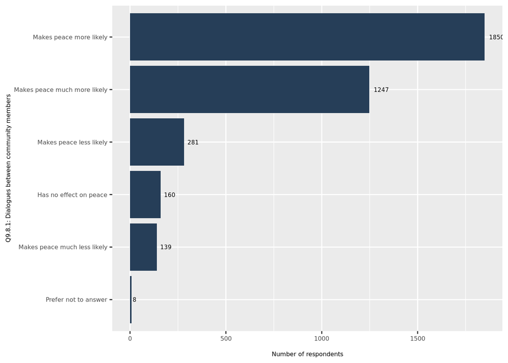

#### By county

| County | Most Common Response | Number of Responses | Percent of Total Responses |
| --- | --- | --- | --- |
| Bor South | Makes peace much more likely | 213 | 100 |
| Kajo-keji | Makes peace more likely | 194 | 100 |
| Lainya | Makes peace more likely | 193 | 100 |
| Malakal | Makes peace more likely | 287 | 100 |
| Morobo | Makes peace more likely | 172 | 100 |
| Pibor | Makes peace more likely | 234 | 100 |
| Rubkona | Makes peace much more likely | 204 | 100 |
| Wau | Makes peace more likely | 173 | 100 |
| Yei | Makes peace more likely | 278 | 100 |

| County | Response | Number of Responses | Percent of Total Responses |
| --- | --- | --- | --- |
| Yei | Has no effect on peace | 19 | 0.05 |
| Yei | Makes peace less likely | 44 | 0.11 |
| Yei | Makes peace more likely | 278 | 0.68 |
| Yei | Makes peace much less likely | 6 | 0.01 |
| Yei | Makes peace much more likely | 63 | 0.15 |
| Wau | Has no effect on peace | 11 | 0.03 |
| Wau | Makes peace less likely | 30 | 0.07 |
| Wau | Makes peace more likely | 173 | 0.43 |
| Wau | Makes peace much less likely | 30 | 0.07 |
| Wau | Makes peace much more likely | 154 | 0.38 |
| Wau | Prefer not to answer | 4 | 0.01 |
| Rubkona | Has no effect on peace | 4 | 0.01 |
| Rubkona | Makes peace less likely | 36 | 0.09 |
| Rubkona | Makes peace more likely | 120 | 0.30 |
| Rubkona | Makes peace much less likely | 35 | 0.09 |
| Rubkona | Makes peace much more likely | 204 | 0.51 |
| Rubkona | Prefer not to answer | 1 | 0.00 |
| Pibor | Has no effect on peace | 49 | 0.12 |
| Pibor | Makes peace less likely | 46 | 0.11 |
| Pibor | Makes peace more likely | 234 | 0.57 |
| Pibor | Makes peace much less likely | 12 | 0.03 |
| Pibor | Makes peace much more likely | 65 | 0.16 |
| Pibor | Prefer not to answer | 1 | 0.00 |
| Morobo | Has no effect on peace | 15 | 0.04 |
| Morobo | Makes peace less likely | 40 | 0.10 |
| Morobo | Makes peace more likely | 172 | 0.43 |
| Morobo | Makes peace much less likely | 29 | 0.07 |
| Morobo | Makes peace much more likely | 148 | 0.37 |
| Malakal | Has no effect on peace | 23 | 0.05 |
| Malakal | Makes peace less likely | 34 | 0.08 |
| Malakal | Makes peace more likely | 287 | 0.68 |
| Malakal | Makes peace much less likely | 1 | 0.00 |
| Malakal | Makes peace much more likely | 76 | 0.18 |
| Lainya | Has no effect on peace | 21 | 0.05 |
| Lainya | Makes peace less likely | 41 | 0.10 |
| Lainya | Makes peace more likely | 193 | 0.47 |
| Lainya | Makes peace much less likely | 12 | 0.03 |
| Lainya | Makes peace much more likely | 146 | 0.35 |
| Lainya | Prefer not to answer | 1 | 0.00 |
| Kajo-keji | Has no effect on peace | 17 | 0.04 |
| Kajo-keji | Makes peace less likely | 7 | 0.02 |
| Kajo-keji | Makes peace more likely | 194 | 0.49 |
| Kajo-keji | Makes peace much less likely | 1 | 0.00 |
| Kajo-keji | Makes peace much more likely | 178 | 0.45 |
| Kajo-keji | Prefer not to answer | 1 | 0.00 |
| Bor South | Has no effect on peace | 1 | 0.00 |
| Bor South | Makes peace less likely | 3 | 0.01 |
| Bor South | Makes peace more likely | 199 | 0.46 |
| Bor South | Makes peace much less likely | 13 | 0.03 |
| Bor South | Makes peace much more likely | 213 | 0.50 |

### **Q9.8.2 Dialogues between representatives of the military and representatives of non-state armed groups**

#### Entire sample

| mean |
| --- |
| NA |

| Most Common Response | Number of Responses | Percent of Total Responses |
| --- | --- | --- |
| Makes peace more likely | 1781 | 100 |

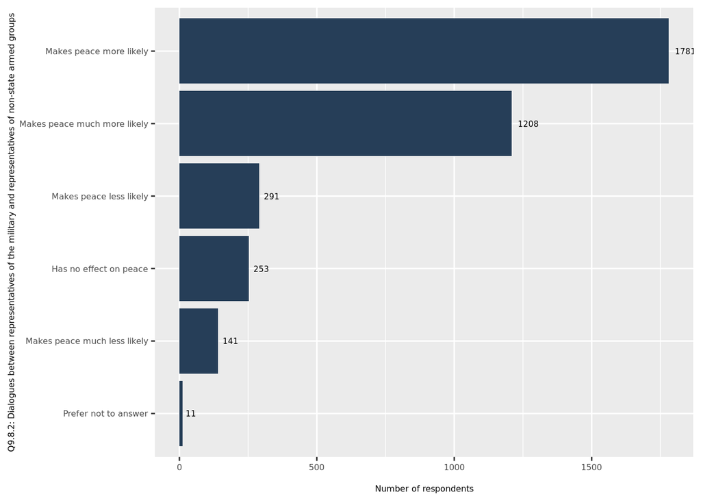

#### By county

| County | Most Common Response | Number of Responses | Percent of Total Responses |
| --- | --- | --- | --- |
| Bor South | Makes peace much more likely | 215 | 100 |
| Kajo-keji | Makes peace much more likely | 179 | 100 |
| Lainya | Makes peace more likely | 188 | 100 |
| Malakal | Makes peace more likely | 280 | 100 |
| Morobo | Makes peace much more likely | 181 | 100 |
| Pibor | Makes peace more likely | 218 | 100 |
| Rubkona | Makes peace much more likely | 177 | 100 |
| Wau | Makes peace more likely | 207 | 100 |
| Yei | Makes peace more likely | 247 | 100 |

| County | Response | Number of Responses | Percent of Total Responses |
| --- | --- | --- | --- |
| Yei | Has no effect on peace | 40 | 0.10 |
| Yei | Makes peace less likely | 43 | 0.10 |
| Yei | Makes peace more likely | 247 | 0.60 |
| Yei | Makes peace much less likely | 11 | 0.03 |
| Yei | Makes peace much more likely | 69 | 0.17 |
| Wau | Has no effect on peace | 25 | 0.06 |
| Wau | Makes peace less likely | 41 | 0.10 |
| Wau | Makes peace more likely | 207 | 0.51 |
| Wau | Makes peace much less likely | 14 | 0.03 |
| Wau | Makes peace much more likely | 111 | 0.28 |
| Wau | Prefer not to answer | 4 | 0.01 |
| Rubkona | Has no effect on peace | 13 | 0.03 |
| Rubkona | Makes peace less likely | 34 | 0.09 |
| Rubkona | Makes peace more likely | 141 | 0.35 |
| Rubkona | Makes peace much less likely | 34 | 0.09 |
| Rubkona | Makes peace much more likely | 177 | 0.44 |
| Rubkona | Prefer not to answer | 1 | 0.00 |
| Pibor | Has no effect on peace | 65 | 0.16 |
| Pibor | Makes peace less likely | 39 | 0.10 |
| Pibor | Makes peace more likely | 218 | 0.54 |
| Pibor | Makes peace much less likely | 25 | 0.06 |
| Pibor | Makes peace much more likely | 59 | 0.14 |
| Pibor | Prefer not to answer | 1 | 0.00 |
| Morobo | Has no effect on peace | 34 | 0.08 |
| Morobo | Makes peace less likely | 31 | 0.08 |
| Morobo | Makes peace more likely | 140 | 0.35 |
| Morobo | Makes peace much less likely | 17 | 0.04 |
| Morobo | Makes peace much more likely | 181 | 0.45 |
| Morobo | Prefer not to answer | 1 | 0.00 |
| Malakal | Has no effect on peace | 18 | 0.04 |
| Malakal | Makes peace less likely | 44 | 0.10 |
| Malakal | Makes peace more likely | 280 | 0.67 |
| Malakal | Makes peace much less likely | 12 | 0.03 |
| Malakal | Makes peace much more likely | 67 | 0.16 |
| Lainya | Has no effect on peace | 31 | 0.07 |
| Lainya | Makes peace less likely | 33 | 0.08 |
| Lainya | Makes peace more likely | 188 | 0.45 |
| Lainya | Makes peace much less likely | 12 | 0.03 |
| Lainya | Makes peace much more likely | 150 | 0.36 |
| Kajo-keji | Has no effect on peace | 19 | 0.05 |
| Kajo-keji | Makes peace less likely | 18 | 0.05 |
| Kajo-keji | Makes peace more likely | 171 | 0.43 |
| Kajo-keji | Makes peace much less likely | 7 | 0.02 |
| Kajo-keji | Makes peace much more likely | 179 | 0.45 |
| Kajo-keji | Prefer not to answer | 4 | 0.01 |
| Bor South | Has no effect on peace | 8 | 0.02 |
| Bor South | Makes peace less likely | 8 | 0.02 |
| Bor South | Makes peace more likely | 189 | 0.44 |
| Bor South | Makes peace much less likely | 9 | 0.02 |
| Bor South | Makes peace much more likely | 215 | 0.50 |

### **Q9.8.3 Inclusion of more WOMEN in dialogues, community leadership, or resource management committees**

#### Entire sample

| mean |
| --- |
| NA |

| Most Common Response | Number of Responses | Percent of Total Responses |
| --- | --- | --- |
| Makes peace more likely | 1707 | 100 |

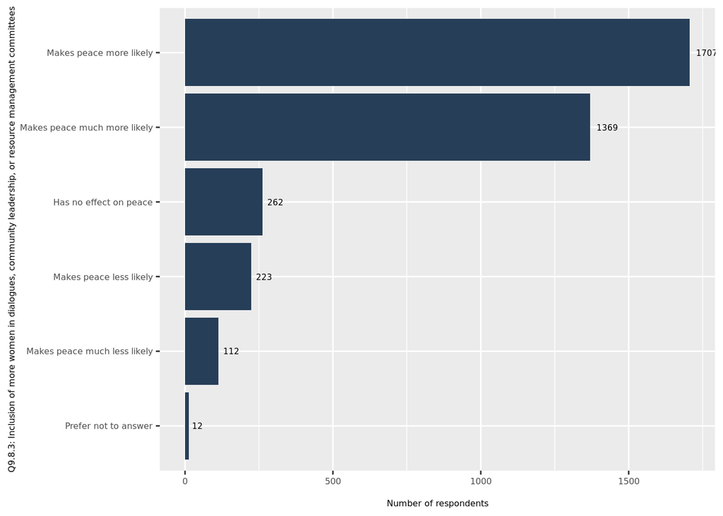

#### By county

| County | Most Common Response | Number of Responses | Percent of Total Responses |
| --- | --- | --- | --- |
| Bor South | Makes peace much more likely | 249 | 100 |
| Kajo-keji | Makes peace more likely | 179 | 100 |
| Lainya | Makes peace more likely | 231 | 100 |
| Malakal | Makes peace more likely | 255 | 100 |
| Morobo | Makes peace more likely | 146 | 100 |
| Pibor | Makes peace more likely | 211 | 100 |
| Rubkona | Makes peace much more likely | 204 | 100 |
| Wau | Makes peace much more likely | 184 | 100 |
| Yei | Makes peace more likely | 245 | 100 |

| County | Response | Number of Responses | Percent of Total Responses |
| --- | --- | --- | --- |
| Yei | Has no effect on peace | 26 | 0.06 |
| Yei | Makes peace less likely | 34 | 0.08 |
| Yei | Makes peace more likely | 245 | 0.60 |
| Yei | Makes peace much less likely | 4 | 0.01 |
| Yei | Makes peace much more likely | 101 | 0.25 |
| Wau | Has no effect on peace | 7 | 0.02 |
| Wau | Makes peace less likely | 28 | 0.07 |
| Wau | Makes peace more likely | 159 | 0.40 |
| Wau | Makes peace much less likely | 18 | 0.04 |
| Wau | Makes peace much more likely | 184 | 0.46 |
| Wau | Prefer not to answer | 6 | 0.01 |
| Rubkona | Has no effect on peace | 12 | 0.03 |
| Rubkona | Makes peace less likely | 43 | 0.11 |
| Rubkona | Makes peace more likely | 118 | 0.30 |
| Rubkona | Makes peace much less likely | 22 | 0.06 |
| Rubkona | Makes peace much more likely | 204 | 0.51 |
| Rubkona | Prefer not to answer | 1 | 0.00 |
| Pibor | Has no effect on peace | 55 | 0.14 |
| Pibor | Makes peace less likely | 28 | 0.07 |
| Pibor | Makes peace more likely | 211 | 0.52 |
| Pibor | Makes peace much less likely | 27 | 0.07 |
| Pibor | Makes peace much more likely | 86 | 0.21 |
| Morobo | Has no effect on peace | 60 | 0.15 |
| Morobo | Makes peace less likely | 28 | 0.07 |
| Morobo | Makes peace more likely | 146 | 0.36 |
| Morobo | Makes peace much less likely | 24 | 0.06 |
| Morobo | Makes peace much more likely | 146 | 0.36 |
| Malakal | Has no effect on peace | 21 | 0.05 |
| Malakal | Makes peace less likely | 4 | 0.01 |
| Malakal | Makes peace more likely | 255 | 0.61 |
| Malakal | Makes peace much more likely | 141 | 0.33 |
| Lainya | Has no effect on peace | 29 | 0.07 |
| Lainya | Makes peace less likely | 26 | 0.06 |
| Lainya | Makes peace more likely | 231 | 0.56 |
| Lainya | Makes peace much less likely | 6 | 0.01 |
| Lainya | Makes peace much more likely | 122 | 0.29 |
| Kajo-keji | Has no effect on peace | 50 | 0.13 |
| Kajo-keji | Makes peace less likely | 28 | 0.07 |
| Kajo-keji | Makes peace more likely | 179 | 0.45 |
| Kajo-keji | Makes peace much less likely | 1 | 0.00 |
| Kajo-keji | Makes peace much more likely | 136 | 0.34 |
| Kajo-keji | Prefer not to answer | 4 | 0.01 |
| Bor South | Has no effect on peace | 2 | 0.00 |
| Bor South | Makes peace less likely | 4 | 0.01 |
| Bor South | Makes peace more likely | 163 | 0.38 |
| Bor South | Makes peace much less likely | 10 | 0.02 |
| Bor South | Makes peace much more likely | 249 | 0.58 |
| Bor South | Prefer not to answer | 1 | 0.00 |

### **Q9.8.4 Inclusion of more YOUTH in dialogues, community leadership, or resource management committees**

#### Entire sample

| mean |
| --- |
| NA |

| Most Common Response | Number of Responses | Percent of Total Responses |
| --- | --- | --- |
| Makes peace more likely | 1703 | 100 |

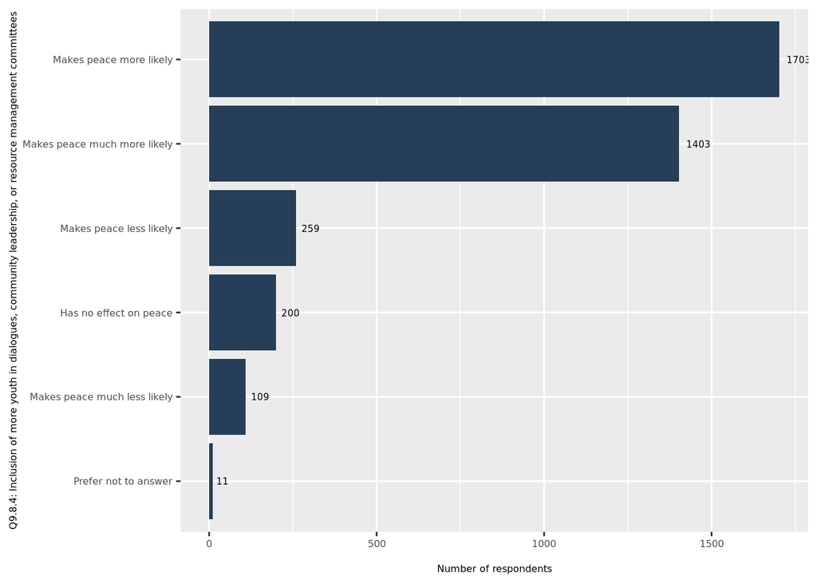

#### By county

| County | Most Common Response | Number of Responses | Percent of Total Responses |
| --- | --- | --- | --- |
| Bor South | Makes peace much more likely | 259 | 100 |
| Kajo-keji | Makes peace more likely | 184 | 100 |
| Lainya | Makes peace more likely | 217 | 100 |
| Malakal | Makes peace more likely | 239 | 100 |
| Morobo | Makes peace much more likely | 170 | 100 |
| Pibor | Makes peace more likely | 220 | 100 |
| Rubkona | Makes peace much more likely | 215 | 100 |
| Wau | Makes peace more likely | 180 | 100 |
| Yei | Makes peace more likely | 239 | 100 |

| County | Response | Number of Responses | Percent of Total Responses |
| --- | --- | --- | --- |
| Yei | Has no effect on peace | 17 | 0.04 |
| Yei | Makes peace less likely | 36 | 0.09 |
| Yei | Makes peace more likely | 239 | 0.58 |
| Yei | Makes peace much less likely | 8 | 0.02 |
| Yei | Makes peace much more likely | 110 | 0.27 |
| Wau | Has no effect on peace | 9 | 0.02 |
| Wau | Makes peace less likely | 37 | 0.09 |
| Wau | Makes peace more likely | 180 | 0.45 |
| Wau | Makes peace much less likely | 17 | 0.04 |
| Wau | Makes peace much more likely | 154 | 0.38 |
| Wau | Prefer not to answer | 5 | 0.01 |
| Rubkona | Has no effect on peace | 5 | 0.01 |
| Rubkona | Makes peace less likely | 39 | 0.10 |
| Rubkona | Makes peace more likely | 121 | 0.30 |
| Rubkona | Makes peace much less likely | 19 | 0.05 |
| Rubkona | Makes peace much more likely | 215 | 0.54 |
| Rubkona | Prefer not to answer | 1 | 0.00 |
| Pibor | Has no effect on peace | 41 | 0.10 |
| Pibor | Makes peace less likely | 29 | 0.07 |
| Pibor | Makes peace more likely | 220 | 0.54 |
| Pibor | Makes peace much less likely | 18 | 0.04 |
| Pibor | Makes peace much more likely | 99 | 0.24 |
| Morobo | Has no effect on peace | 26 | 0.06 |
| Morobo | Makes peace less likely | 30 | 0.07 |
| Morobo | Makes peace more likely | 149 | 0.37 |
| Morobo | Makes peace much less likely | 29 | 0.07 |
| Morobo | Makes peace much more likely | 170 | 0.42 |
| Malakal | Has no effect on peace | 19 | 0.05 |
| Malakal | Makes peace less likely | 26 | 0.06 |
| Malakal | Makes peace more likely | 239 | 0.57 |
| Malakal | Makes peace much less likely | 1 | 0.00 |
| Malakal | Makes peace much more likely | 136 | 0.32 |
| Lainya | Has no effect on peace | 33 | 0.08 |
| Lainya | Makes peace less likely | 27 | 0.07 |
| Lainya | Makes peace more likely | 217 | 0.52 |
| Lainya | Makes peace much less likely | 8 | 0.02 |
| Lainya | Makes peace much more likely | 129 | 0.31 |
| Kajo-keji | Has no effect on peace | 47 | 0.12 |
| Kajo-keji | Makes peace less likely | 29 | 0.07 |
| Kajo-keji | Makes peace more likely | 184 | 0.46 |
| Kajo-keji | Makes peace much less likely | 2 | 0.01 |
| Kajo-keji | Makes peace much more likely | 131 | 0.33 |
| Kajo-keji | Prefer not to answer | 5 | 0.01 |
| Bor South | Has no effect on peace | 3 | 0.01 |
| Bor South | Makes peace less likely | 6 | 0.01 |
| Bor South | Makes peace more likely | 154 | 0.36 |
| Bor South | Makes peace much less likely | 7 | 0.02 |
| Bor South | Makes peace much more likely | 259 | 0.60 |

### **Q9.8.5 Confessions by perpetrators of violence or crimes**

#### Entire sample

| mean |
| --- |
| NA |

| Most Common Response | Number of Responses | Percent of Total Responses |
| --- | --- | --- |
| Makes peace more likely | 1487 | 100 |

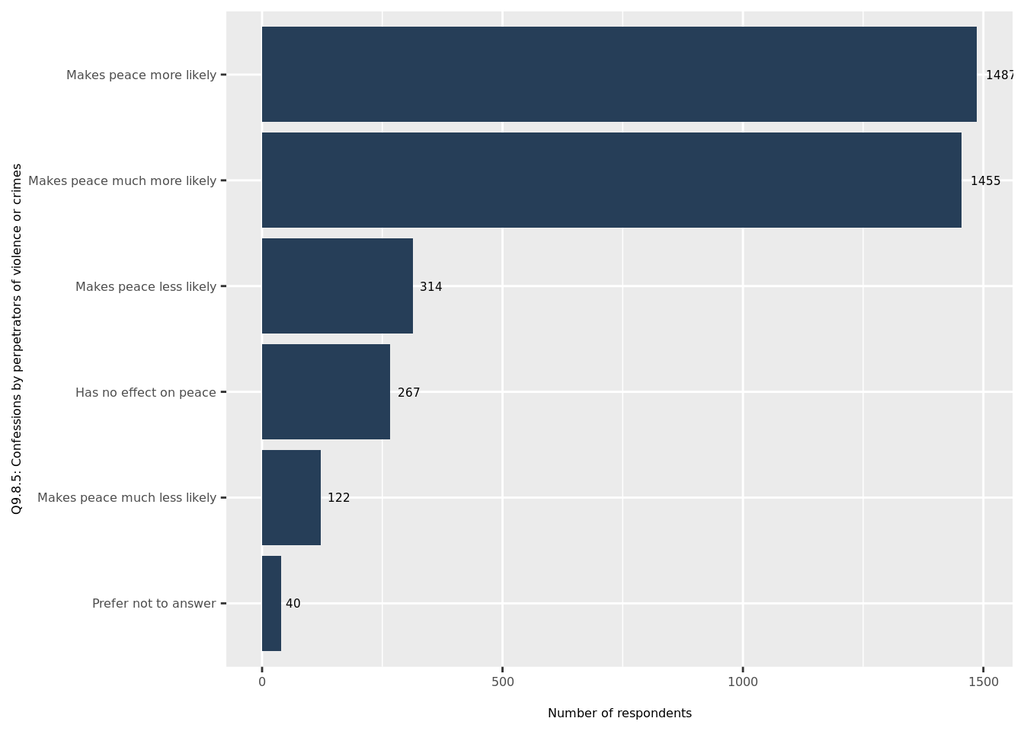

#### By county

| County | Most Common Response | Number of Responses | Percent of Total Responses |
| --- | --- | --- | --- |
| Bor South | Makes peace much more likely | 206 | 100 |
| Kajo-keji | Makes peace much more likely | 166 | 100 |
| Lainya | Makes peace more likely | 180 | 100 |
| Malakal | Makes peace more likely | 238 | 100 |
| Morobo | Makes peace much more likely | 190 | 100 |
| Pibor | Makes peace more likely | 176 | 100 |
| Rubkona | Makes peace much more likely | 229 | 100 |
| Wau | Makes peace much more likely | 162 | 100 |
| Yei | Makes peace more likely | 201 | 100 |

| County | Response | Number of Responses | Percent of Total Responses |
| --- | --- | --- | --- |
| Yei | Has no effect on peace | 31 | 0.08 |
| Yei | Makes peace less likely | 21 | 0.05 |
| Yei | Makes peace more likely | 201 | 0.49 |
| Yei | Makes peace much less likely | 3 | 0.01 |
| Yei | Makes peace much more likely | 153 | 0.37 |
| Yei | Prefer not to answer | 1 | 0.00 |
| Wau | Has no effect on peace | 12 | 0.03 |
| Wau | Makes peace less likely | 41 | 0.10 |
| Wau | Makes peace more likely | 150 | 0.37 |
| Wau | Makes peace much less likely | 24 | 0.06 |
| Wau | Makes peace much more likely | 162 | 0.40 |
| Wau | Prefer not to answer | 13 | 0.03 |
| Rubkona | Has no effect on peace | 27 | 0.07 |
| Rubkona | Makes peace less likely | 30 | 0.07 |
| Rubkona | Makes peace more likely | 92 | 0.23 |
| Rubkona | Makes peace much less likely | 21 | 0.05 |
| Rubkona | Makes peace much more likely | 229 | 0.57 |
| Rubkona | Prefer not to answer | 1 | 0.00 |
| Pibor | Has no effect on peace | 52 | 0.13 |
| Pibor | Makes peace less likely | 47 | 0.12 |
| Pibor | Makes peace more likely | 176 | 0.43 |
| Pibor | Makes peace much less likely | 28 | 0.07 |
| Pibor | Makes peace much more likely | 102 | 0.25 |
| Pibor | Prefer not to answer | 2 | 0.00 |
| Morobo | Has no effect on peace | 38 | 0.09 |
| Morobo | Makes peace less likely | 35 | 0.09 |
| Morobo | Makes peace more likely | 129 | 0.32 |
| Morobo | Makes peace much less likely | 12 | 0.03 |
| Morobo | Makes peace much more likely | 190 | 0.47 |
| Malakal | Has no effect on peace | 26 | 0.06 |
| Malakal | Makes peace less likely | 64 | 0.15 |
| Malakal | Makes peace more likely | 238 | 0.57 |
| Malakal | Makes peace much more likely | 93 | 0.22 |
| Lainya | Has no effect on peace | 45 | 0.11 |
| Lainya | Makes peace less likely | 23 | 0.06 |
| Lainya | Makes peace more likely | 180 | 0.43 |
| Lainya | Makes peace much less likely | 9 | 0.02 |
| Lainya | Makes peace much more likely | 154 | 0.37 |
| Lainya | Prefer not to answer | 3 | 0.01 |
| Kajo-keji | Has no effect on peace | 20 | 0.05 |
| Kajo-keji | Makes peace less likely | 27 | 0.07 |
| Kajo-keji | Makes peace more likely | 160 | 0.40 |
| Kajo-keji | Makes peace much less likely | 7 | 0.02 |
| Kajo-keji | Makes peace much more likely | 166 | 0.42 |
| Kajo-keji | Prefer not to answer | 18 | 0.05 |
| Bor South | Has no effect on peace | 16 | 0.04 |
| Bor South | Makes peace less likely | 26 | 0.06 |
| Bor South | Makes peace more likely | 161 | 0.38 |
| Bor South | Makes peace much less likely | 18 | 0.04 |
| Bor South | Makes peace much more likely | 206 | 0.48 |
| Bor South | Prefer not to answer | 2 | 0.00 |

### **Q9.8.6 Apologies by perpetrators of violence or crimes**

#### Entire sample

| mean |
| --- |
| NA |

| Most Common Response | Number of Responses | Percent of Total Responses |
| --- | --- | --- |
| Makes peace more likely | 1689 | 100 |

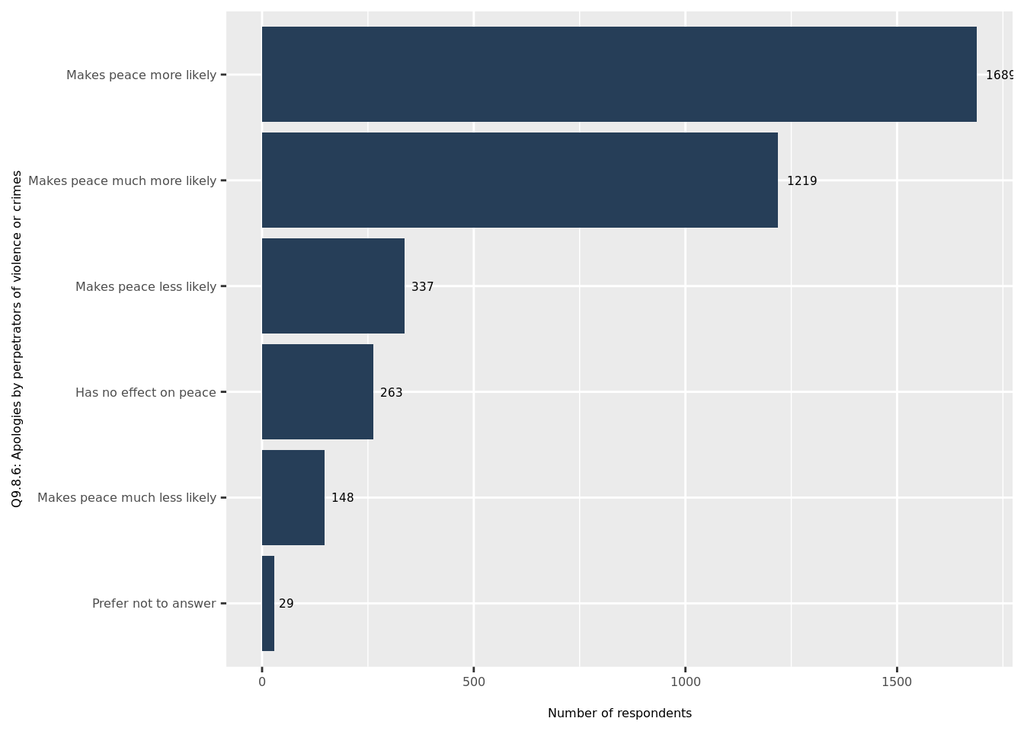

#### By county

| County | Most Common Response | Number of Responses | Percent of Total Responses |
| --- | --- | --- | --- |
| Bor South | Makes peace more likely | 186 | 100 |
| Kajo-keji | Makes peace more likely | 174 | 100 |
| Lainya | Makes peace more likely | 199 | 100 |
| Malakal | Makes peace more likely | 281 | 100 |
| Morobo | Makes peace much more likely | 168 | 100 |
| Pibor | Makes peace more likely | 183 | 100 |
| Rubkona | Makes peace much more likely | 195 | 100 |
| Wau | Makes peace more likely | 173 | 100 |
| Yei | Makes peace more likely | 243 | 100 |

| County | Response | Number of Responses | Percent of Total Responses |
| --- | --- | --- | --- |
| Yei | Has no effect on peace | 28 | 0.07 |
| Yei | Makes peace less likely | 24 | 0.06 |
| Yei | Makes peace more likely | 243 | 0.59 |
| Yei | Makes peace much less likely | 5 | 0.01 |
| Yei | Makes peace much more likely | 110 | 0.27 |
| Wau | Has no effect on peace | 16 | 0.04 |
| Wau | Makes peace less likely | 49 | 0.12 |
| Wau | Makes peace more likely | 173 | 0.43 |
| Wau | Makes peace much less likely | 19 | 0.05 |
| Wau | Makes peace much more likely | 136 | 0.34 |
| Wau | Prefer not to answer | 9 | 0.02 |
| Rubkona | Has no effect on peace | 13 | 0.03 |
| Rubkona | Makes peace less likely | 42 | 0.10 |
| Rubkona | Makes peace more likely | 120 | 0.30 |
| Rubkona | Makes peace much less likely | 29 | 0.07 |
| Rubkona | Makes peace much more likely | 195 | 0.49 |
| Rubkona | Prefer not to answer | 1 | 0.00 |
| Pibor | Has no effect on peace | 57 | 0.14 |
| Pibor | Makes peace less likely | 50 | 0.12 |
| Pibor | Makes peace more likely | 183 | 0.45 |
| Pibor | Makes peace much less likely | 36 | 0.09 |
| Pibor | Makes peace much more likely | 79 | 0.19 |
| Pibor | Prefer not to answer | 2 | 0.00 |
| Morobo | Has no effect on peace | 37 | 0.09 |
| Morobo | Makes peace less likely | 46 | 0.11 |
| Morobo | Makes peace more likely | 130 | 0.32 |
| Morobo | Makes peace much less likely | 23 | 0.06 |
| Morobo | Makes peace much more likely | 168 | 0.42 |
| Malakal | Has no effect on peace | 18 | 0.04 |
| Malakal | Makes peace less likely | 54 | 0.13 |
| Malakal | Makes peace more likely | 281 | 0.67 |
| Malakal | Makes peace much less likely | 2 | 0.00 |
| Malakal | Makes peace much more likely | 66 | 0.16 |
| Lainya | Has no effect on peace | 34 | 0.08 |
| Lainya | Makes peace less likely | 22 | 0.05 |
| Lainya | Makes peace more likely | 199 | 0.48 |
| Lainya | Makes peace much less likely | 12 | 0.03 |
| Lainya | Makes peace much more likely | 144 | 0.35 |
| Lainya | Prefer not to answer | 3 | 0.01 |
| Kajo-keji | Has no effect on peace | 29 | 0.07 |
| Kajo-keji | Makes peace less likely | 28 | 0.07 |
| Kajo-keji | Makes peace more likely | 174 | 0.44 |
| Kajo-keji | Makes peace much less likely | 7 | 0.02 |
| Kajo-keji | Makes peace much more likely | 146 | 0.37 |
| Kajo-keji | Prefer not to answer | 14 | 0.04 |
| Bor South | Has no effect on peace | 31 | 0.07 |
| Bor South | Makes peace less likely | 22 | 0.05 |
| Bor South | Makes peace more likely | 186 | 0.43 |
| Bor South | Makes peace much less likely | 15 | 0.03 |
| Bor South | Makes peace much more likely | 175 | 0.41 |

### **Q9.8.7 Rehabilitation programs for perpetrators of violence or crimes**

#### Entire sample

| mean |
| --- |
| NA |

| Most Common Response | Number of Responses | Percent of Total Responses |
| --- | --- | --- |
| Makes peace more likely | 1764 | 100 |

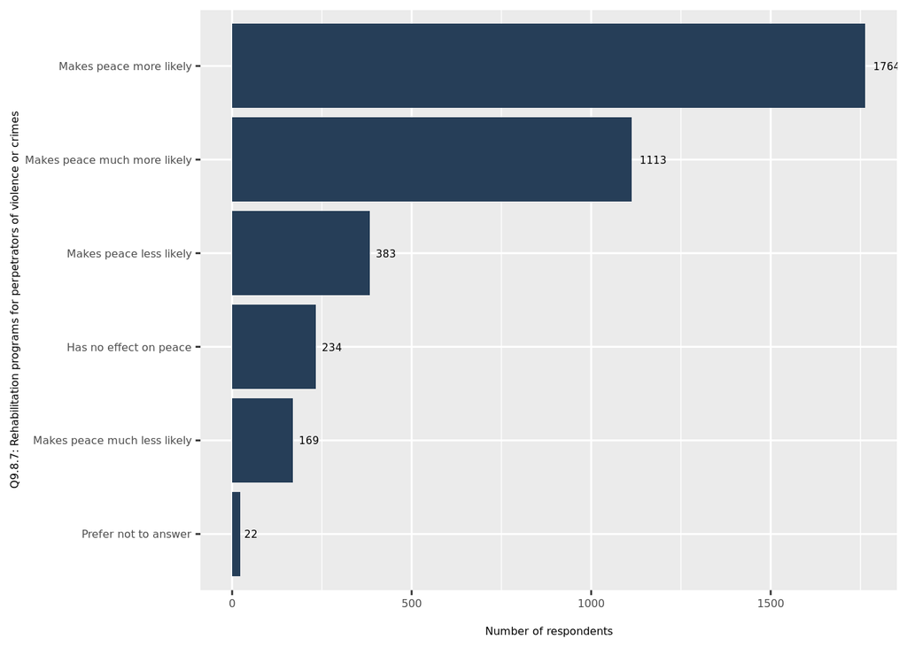

#### By county

| County | Most Common Response | Number of Responses | Percent of Total Responses |
| --- | --- | --- | --- |
| Bor South | Makes peace more likely | 209 | 100 |
| Kajo-keji | Makes peace more likely | 191 | 100 |
| Lainya | Makes peace more likely | 214 | 100 |
| Malakal | Makes peace more likely | 259 | 100 |
| Morobo | Makes peace much more likely | 158 | 100 |
| Pibor | Makes peace more likely | 187 | 100 |
| Rubkona | Makes peace much more likely | 177 | 100 |
| Wau | Makes peace more likely | 184 | 100 |
| Yei | Makes peace more likely | 257 | 100 |

| County | Response | Number of Responses | Percent of Total Responses |
| --- | --- | --- | --- |
| Yei | Has no effect on peace | 23 | 0.06 |
| Yei | Makes peace less likely | 37 | 0.09 |
| Yei | Makes peace more likely | 257 | 0.63 |
| Yei | Makes peace much less likely | 5 | 0.01 |
| Yei | Makes peace much more likely | 88 | 0.21 |
| Wau | Has no effect on peace | 17 | 0.04 |
| Wau | Makes peace less likely | 36 | 0.09 |
| Wau | Makes peace more likely | 184 | 0.46 |
| Wau | Makes peace much less likely | 23 | 0.06 |
| Wau | Makes peace much more likely | 135 | 0.34 |
| Wau | Prefer not to answer | 7 | 0.02 |
| Rubkona | Has no effect on peace | 9 | 0.02 |
| Rubkona | Makes peace less likely | 59 | 0.15 |
| Rubkona | Makes peace more likely | 123 | 0.31 |
| Rubkona | Makes peace much less likely | 31 | 0.08 |
| Rubkona | Makes peace much more likely | 177 | 0.44 |
| Rubkona | Prefer not to answer | 1 | 0.00 |
| Pibor | Has no effect on peace | 65 | 0.16 |
| Pibor | Makes peace less likely | 53 | 0.13 |
| Pibor | Makes peace more likely | 187 | 0.46 |
| Pibor | Makes peace much less likely | 34 | 0.08 |
| Pibor | Makes peace much more likely | 67 | 0.16 |
| Pibor | Prefer not to answer | 1 | 0.00 |
| Morobo | Has no effect on peace | 25 | 0.06 |
| Morobo | Makes peace less likely | 48 | 0.12 |
| Morobo | Makes peace more likely | 140 | 0.35 |
| Morobo | Makes peace much less likely | 33 | 0.08 |
| Morobo | Makes peace much more likely | 158 | 0.39 |
| Malakal | Has no effect on peace | 21 | 0.05 |
| Malakal | Makes peace less likely | 63 | 0.15 |
| Malakal | Makes peace more likely | 259 | 0.62 |
| Malakal | Makes peace much less likely | 3 | 0.01 |
| Malakal | Makes peace much more likely | 75 | 0.18 |
| Lainya | Has no effect on peace | 32 | 0.08 |
| Lainya | Makes peace less likely | 33 | 0.08 |
| Lainya | Makes peace more likely | 214 | 0.52 |
| Lainya | Makes peace much less likely | 12 | 0.03 |
| Lainya | Makes peace much more likely | 122 | 0.29 |
| Lainya | Prefer not to answer | 1 | 0.00 |
| Kajo-keji | Has no effect on peace | 20 | 0.05 |
| Kajo-keji | Makes peace less likely | 34 | 0.09 |
| Kajo-keji | Makes peace more likely | 191 | 0.48 |
| Kajo-keji | Makes peace much less likely | 8 | 0.02 |
| Kajo-keji | Makes peace much more likely | 133 | 0.33 |
| Kajo-keji | Prefer not to answer | 12 | 0.03 |
| Bor South | Has no effect on peace | 22 | 0.05 |
| Bor South | Makes peace less likely | 20 | 0.05 |
| Bor South | Makes peace more likely | 209 | 0.49 |
| Bor South | Makes peace much less likely | 20 | 0.05 |
| Bor South | Makes peace much more likely | 158 | 0.37 |

### **Q9.8.8 Criminal prosecutions for perpetrators of violence or crimes**

#### Entire sample

| mean |
| --- |
| NA |

| Most Common Response | Number of Responses | Percent of Total Responses |
| --- | --- | --- |
| Makes peace more likely | 1534 | 100 |

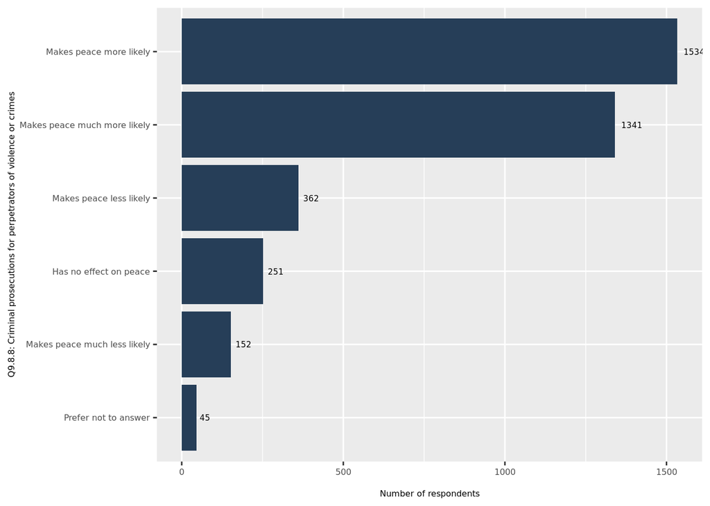

#### By county

| County | Most Common Response | Number of Responses | Percent of Total Responses |
| --- | --- | --- | --- |
| Bor South | Makes peace much more likely | 236 | 100 |
| Kajo-keji | Makes peace more likely | 163 | 100 |
| Lainya | Makes peace more likely | 184 | 100 |
| Malakal | Makes peace more likely | 248 | 100 |
| Morobo | Makes peace much more likely | 187 | 100 |
| Pibor | Makes peace more likely | 186 | 100 |
| Rubkona | Makes peace much more likely | 207 | 100 |
| Wau | Makes peace more likely | 164 | 100 |
| Yei | Makes peace more likely | 212 | 100 |

| County | Response | Number of Responses | Percent of Total Responses |
| --- | --- | --- | --- |
| Yei | Has no effect on peace | 29 | 0.07 |
| Yei | Makes peace less likely | 24 | 0.06 |
| Yei | Makes peace more likely | 212 | 0.52 |
| Yei | Makes peace much less likely | 6 | 0.01 |
| Yei | Makes peace much more likely | 139 | 0.34 |
| Wau | Has no effect on peace | 18 | 0.04 |
| Wau | Makes peace less likely | 46 | 0.11 |
| Wau | Makes peace more likely | 164 | 0.41 |
| Wau | Makes peace much less likely | 24 | 0.06 |
| Wau | Makes peace much more likely | 125 | 0.31 |
| Wau | Prefer not to answer | 25 | 0.06 |
| Rubkona | Has no effect on peace | 12 | 0.03 |
| Rubkona | Makes peace less likely | 53 | 0.13 |
| Rubkona | Makes peace more likely | 100 | 0.25 |
| Rubkona | Makes peace much less likely | 27 | 0.07 |
| Rubkona | Makes peace much more likely | 207 | 0.52 |
| Rubkona | Prefer not to answer | 1 | 0.00 |
| Pibor | Has no effect on peace | 68 | 0.17 |
| Pibor | Makes peace less likely | 47 | 0.12 |
| Pibor | Makes peace more likely | 186 | 0.46 |
| Pibor | Makes peace much less likely | 25 | 0.06 |
| Pibor | Makes peace much more likely | 80 | 0.20 |
| Pibor | Prefer not to answer | 1 | 0.00 |
| Morobo | Has no effect on peace | 36 | 0.09 |
| Morobo | Makes peace less likely | 36 | 0.09 |
| Morobo | Makes peace more likely | 121 | 0.30 |
| Morobo | Makes peace much less likely | 24 | 0.06 |
| Morobo | Makes peace much more likely | 187 | 0.46 |
| Malakal | Has no effect on peace | 32 | 0.08 |
| Malakal | Makes peace less likely | 56 | 0.13 |
| Malakal | Makes peace more likely | 248 | 0.59 |
| Malakal | Makes peace much less likely | 7 | 0.02 |
| Malakal | Makes peace much more likely | 78 | 0.19 |
| Lainya | Has no effect on peace | 35 | 0.08 |
| Lainya | Makes peace less likely | 29 | 0.07 |
| Lainya | Makes peace more likely | 184 | 0.44 |
| Lainya | Makes peace much less likely | 15 | 0.04 |
| Lainya | Makes peace much more likely | 147 | 0.36 |
| Lainya | Prefer not to answer | 4 | 0.01 |
| Kajo-keji | Has no effect on peace | 20 | 0.05 |
| Kajo-keji | Makes peace less likely | 49 | 0.12 |
| Kajo-keji | Makes peace more likely | 163 | 0.41 |
| Kajo-keji | Makes peace much less likely | 10 | 0.03 |
| Kajo-keji | Makes peace much more likely | 142 | 0.36 |
| Kajo-keji | Prefer not to answer | 14 | 0.04 |
| Bor South | Has no effect on peace | 1 | 0.00 |
| Bor South | Makes peace less likely | 22 | 0.05 |
| Bor South | Makes peace more likely | 156 | 0.36 |
| Bor South | Makes peace much less likely | 14 | 0.03 |
| Bor South | Makes peace much more likely | 236 | 0.55 |

### **Q9.8.9 A commission to discover the truth about the conflict**

#### Entire sample

| mean |
| --- |
| NA |

| Most Common Response | Number of Responses | Percent of Total Responses |
| --- | --- | --- |
| Makes peace more likely | 1626 | 100 |

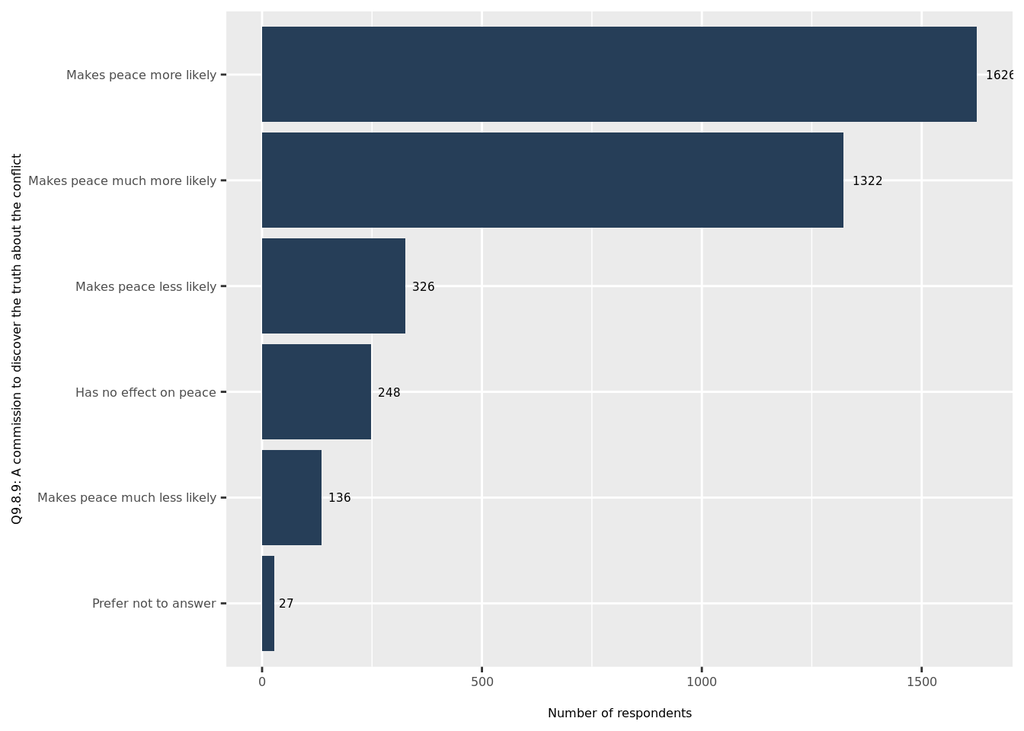

#### By county

| County | Most Common Response | Number of Responses | Percent of Total Responses |
| --- | --- | --- | --- |
| Bor South | Makes peace much more likely | 204 | 100 |
| Kajo-keji | Makes peace much more likely | 177 | 100 |
| Lainya | Makes peace more likely | 195 | 100 |
| Malakal | Makes peace more likely | 230 | 100 |
| Morobo | Makes peace much more likely | 153 | 100 |
| Pibor | Makes peace more likely | 183 | 100 |
| Rubkona | Makes peace much more likely | 232 | 100 |
| Wau | Makes peace more likely | 188 | 100 |
| Yei | Makes peace more likely | 259 | 100 |

| County | Response | Number of Responses | Percent of Total Responses |
| --- | --- | --- | --- |
| Yei | Has no effect on peace | 22 | 0.05 |
| Yei | Makes peace less likely | 30 | 0.07 |
| Yei | Makes peace more likely | 259 | 0.63 |
| Yei | Makes peace much less likely | 6 | 0.01 |
| Yei | Makes peace much more likely | 93 | 0.23 |
| Wau | Has no effect on peace | 17 | 0.04 |
| Wau | Makes peace less likely | 47 | 0.12 |
| Wau | Makes peace more likely | 188 | 0.47 |
| Wau | Makes peace much less likely | 27 | 0.07 |
| Wau | Makes peace much more likely | 115 | 0.29 |
| Wau | Prefer not to answer | 8 | 0.02 |
| Rubkona | Has no effect on peace | 4 | 0.01 |
| Rubkona | Makes peace less likely | 44 | 0.11 |
| Rubkona | Makes peace more likely | 92 | 0.23 |
| Rubkona | Makes peace much less likely | 28 | 0.07 |
| Rubkona | Makes peace much more likely | 232 | 0.58 |
| Pibor | Has no effect on peace | 62 | 0.15 |
| Pibor | Makes peace less likely | 33 | 0.08 |
| Pibor | Makes peace more likely | 183 | 0.45 |
| Pibor | Makes peace much less likely | 17 | 0.04 |
| Pibor | Makes peace much more likely | 111 | 0.27 |
| Pibor | Prefer not to answer | 1 | 0.00 |
| Morobo | Has no effect on peace | 45 | 0.11 |
| Morobo | Makes peace less likely | 38 | 0.09 |
| Morobo | Makes peace more likely | 142 | 0.35 |
| Morobo | Makes peace much less likely | 26 | 0.06 |
| Morobo | Makes peace much more likely | 153 | 0.38 |
| Malakal | Has no effect on peace | 17 | 0.04 |
| Malakal | Makes peace less likely | 62 | 0.15 |
| Malakal | Makes peace more likely | 230 | 0.55 |
| Malakal | Makes peace much less likely | 7 | 0.02 |
| Malakal | Makes peace much more likely | 105 | 0.25 |
| Lainya | Has no effect on peace | 50 | 0.12 |
| Lainya | Makes peace less likely | 30 | 0.07 |
| Lainya | Makes peace more likely | 195 | 0.47 |
| Lainya | Makes peace much less likely | 6 | 0.01 |
| Lainya | Makes peace much more likely | 132 | 0.32 |
| Lainya | Prefer not to answer | 1 | 0.00 |
| Kajo-keji | Has no effect on peace | 23 | 0.06 |
| Kajo-keji | Makes peace less likely | 34 | 0.09 |
| Kajo-keji | Makes peace more likely | 144 | 0.36 |
| Kajo-keji | Makes peace much less likely | 3 | 0.01 |
| Kajo-keji | Makes peace much more likely | 177 | 0.44 |
| Kajo-keji | Prefer not to answer | 17 | 0.04 |
| Bor South | Has no effect on peace | 8 | 0.02 |
| Bor South | Makes peace less likely | 8 | 0.02 |
| Bor South | Makes peace more likely | 193 | 0.45 |
| Bor South | Makes peace much less likely | 16 | 0.04 |
| Bor South | Makes peace much more likely | 204 | 0.48 |

### **Q9.8.10 A museum about the conflict**

#### Entire sample

| mean |
| --- |
| NA |

| Most Common Response | Number of Responses | Percent of Total Responses |
| --- | --- | --- |
| Makes peace more likely | 1524 | 100 |

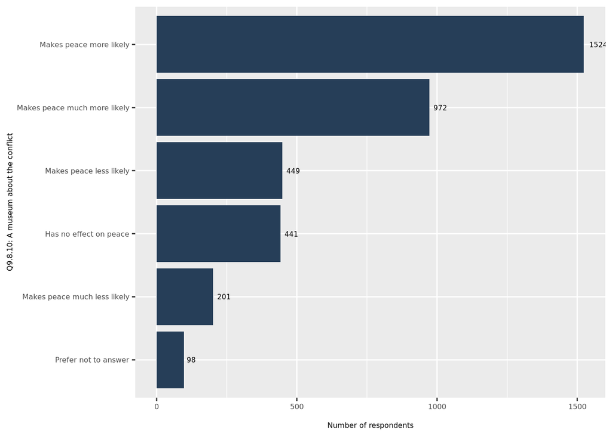

#### By county

| County | Most Common Response | Number of Responses | Percent of Total Responses |
| --- | --- | --- | --- |
| Bor South | Makes peace more likely | 182 | 100 |
| Kajo-keji | Makes peace more likely | 161 | 100 |
| Lainya | Makes peace more likely | 167 | 100 |
| Malakal | Makes peace more likely | 246 | 100 |
| Morobo | Makes peace much more likely | 108 | 100 |
| Pibor | Makes peace more likely | 171 | 100 |
| Rubkona | Makes peace much more likely | 176 | 100 |
| Wau | Makes peace more likely | 141 | 100 |
| Yei | Makes peace more likely | 235 | 100 |

| County | Response | Number of Responses | Percent of Total Responses |
| --- | --- | --- | --- |
| Yei | Has no effect on peace | 39 | 0.10 |
| Yei | Makes peace less likely | 49 | 0.12 |
| Yei | Makes peace more likely | 235 | 0.57 |
| Yei | Makes peace much less likely | 10 | 0.02 |
| Yei | Makes peace much more likely | 76 | 0.19 |
| Yei | Prefer not to answer | 1 | 0.00 |
| Wau | Has no effect on peace | 18 | 0.04 |
| Wau | Makes peace less likely | 31 | 0.08 |
| Wau | Makes peace more likely | 141 | 0.35 |
| Wau | Makes peace much less likely | 34 | 0.08 |
| Wau | Makes peace much more likely | 119 | 0.30 |
| Wau | Prefer not to answer | 59 | 0.15 |
| Rubkona | Has no effect on peace | 9 | 0.02 |
| Rubkona | Makes peace less likely | 58 | 0.14 |
| Rubkona | Makes peace more likely | 123 | 0.31 |
| Rubkona | Makes peace much less likely | 33 | 0.08 |
| Rubkona | Makes peace much more likely | 176 | 0.44 |
| Rubkona | Prefer not to answer | 1 | 0.00 |
| Pibor | Has no effect on peace | 78 | 0.19 |
| Pibor | Makes peace less likely | 44 | 0.11 |
| Pibor | Makes peace more likely | 171 | 0.42 |
| Pibor | Makes peace much less likely | 32 | 0.08 |
| Pibor | Makes peace much more likely | 74 | 0.18 |
| Pibor | Prefer not to answer | 8 | 0.02 |
| Morobo | Has no effect on peace | 77 | 0.19 |
| Morobo | Makes peace less likely | 80 | 0.20 |
| Morobo | Makes peace more likely | 98 | 0.24 |
| Morobo | Makes peace much less likely | 38 | 0.09 |
| Morobo | Makes peace much more likely | 108 | 0.27 |
| Morobo | Prefer not to answer | 3 | 0.01 |
| Malakal | Has no effect on peace | 34 | 0.08 |
| Malakal | Makes peace less likely | 66 | 0.16 |
| Malakal | Makes peace more likely | 246 | 0.58 |
| Malakal | Makes peace much less likely | 5 | 0.01 |
| Malakal | Makes peace much more likely | 70 | 0.17 |
| Lainya | Has no effect on peace | 75 | 0.18 |
| Lainya | Makes peace less likely | 48 | 0.12 |
| Lainya | Makes peace more likely | 167 | 0.40 |
| Lainya | Makes peace much less likely | 18 | 0.04 |
| Lainya | Makes peace much more likely | 101 | 0.24 |
| Lainya | Prefer not to answer | 5 | 0.01 |
| Kajo-keji | Has no effect on peace | 48 | 0.12 |
| Kajo-keji | Makes peace less likely | 41 | 0.10 |
| Kajo-keji | Makes peace more likely | 161 | 0.40 |
| Kajo-keji | Makes peace much less likely | 16 | 0.04 |
| Kajo-keji | Makes peace much more likely | 111 | 0.28 |
| Kajo-keji | Prefer not to answer | 21 | 0.05 |
| Bor South | Has no effect on peace | 63 | 0.15 |
| Bor South | Makes peace less likely | 32 | 0.07 |
| Bor South | Makes peace more likely | 182 | 0.42 |
| Bor South | Makes peace much less likely | 15 | 0.03 |
| Bor South | Makes peace much more likely | 137 | 0.32 |

### **Q9.8.11 Compensation or other reparations for victims**

#### Entire sample

| mean |
| --- |
| NA |

| Most Common Response | Number of Responses | Percent of Total Responses |
| --- | --- | --- |
| Makes peace more likely | 1633 | 100 |

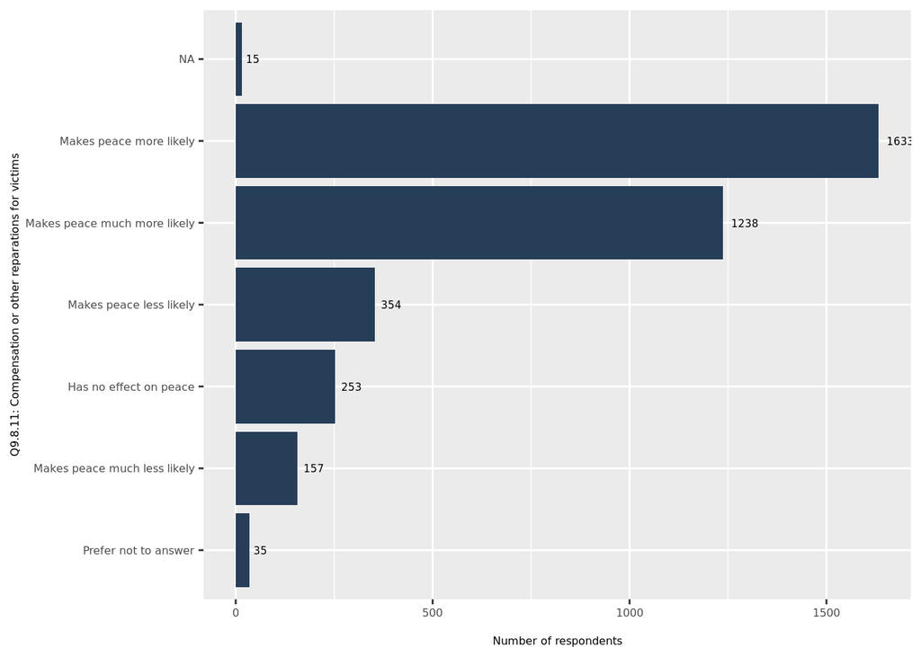

#### By county

| County | Most Common Response | Number of Responses | Percent of Total Responses |
| --- | --- | --- | --- |
| Bor South | Makes peace much more likely | 206 | 100 |
| Kajo-keji | Makes peace more likely | 154 | 100 |
| Lainya | Makes peace more likely | 180 | 100 |
| Malakal | Makes peace more likely | 261 | 100 |
| Morobo | Makes peace much more likely | 170 | 100 |
| Pibor | Makes peace more likely | 197 | 100 |
| Rubkona | Makes peace much more likely | 211 | 100 |
| Wau | Makes peace more likely | 162 | 100 |
| Yei | Makes peace more likely | 241 | 100 |

| County | Response | Number of Responses | Percent of Total Responses |
| --- | --- | --- | --- |
| Yei | Has no effect on peace | 34 | 0.08 |
| Yei | Makes peace less likely | 31 | 0.08 |
| Yei | Makes peace more likely | 241 | 0.59 |
| Yei | Makes peace much less likely | 5 | 0.01 |
| Yei | Makes peace much more likely | 98 | 0.24 |
| Yei | Prefer not to answer | 1 | 0.00 |
| Wau | Has no effect on peace | 12 | 0.03 |
| Wau | Makes peace less likely | 60 | 0.15 |
| Wau | Makes peace more likely | 162 | 0.40 |
| Wau | Makes peace much less likely | 29 | 0.07 |
| Wau | Makes peace much more likely | 129 | 0.32 |
| Wau | Prefer not to answer | 7 | 0.02 |
| Wau | NA | 3 | 0.01 |
| Rubkona | Has no effect on peace | 4 | 0.01 |
| Rubkona | Makes peace less likely | 35 | 0.09 |
| Rubkona | Makes peace more likely | 116 | 0.29 |
| Rubkona | Makes peace much less likely | 32 | 0.08 |
| Rubkona | Makes peace much more likely | 211 | 0.53 |
| Rubkona | Prefer not to answer | 1 | 0.00 |
| Rubkona | NA | 1 | 0.00 |
| Pibor | Has no effect on peace | 66 | 0.16 |
| Pibor | Makes peace less likely | 46 | 0.11 |
| Pibor | Makes peace more likely | 197 | 0.48 |
| Pibor | Makes peace much less likely | 19 | 0.05 |
| Pibor | Makes peace much more likely | 77 | 0.19 |
| Pibor | Prefer not to answer | 2 | 0.00 |
| Morobo | Has no effect on peace | 42 | 0.10 |
| Morobo | Makes peace less likely | 37 | 0.09 |
| Morobo | Makes peace more likely | 126 | 0.31 |
| Morobo | Makes peace much less likely | 26 | 0.06 |
| Morobo | Makes peace much more likely | 170 | 0.42 |
| Morobo | NA | 3 | 0.01 |
| Malakal | Has no effect on peace | 24 | 0.06 |
| Malakal | Makes peace less likely | 63 | 0.15 |
| Malakal | Makes peace more likely | 261 | 0.62 |
| Malakal | Makes peace much less likely | 1 | 0.00 |
| Malakal | Makes peace much more likely | 72 | 0.17 |
| Lainya | Has no effect on peace | 45 | 0.11 |
| Lainya | Makes peace less likely | 32 | 0.08 |
| Lainya | Makes peace more likely | 180 | 0.43 |
| Lainya | Makes peace much less likely | 14 | 0.03 |
| Lainya | Makes peace much more likely | 142 | 0.34 |
| Lainya | Prefer not to answer | 1 | 0.00 |
| Kajo-keji | Has no effect on peace | 24 | 0.06 |
| Kajo-keji | Makes peace less likely | 41 | 0.10 |
| Kajo-keji | Makes peace more likely | 154 | 0.39 |
| Kajo-keji | Makes peace much less likely | 16 | 0.04 |
| Kajo-keji | Makes peace much more likely | 133 | 0.33 |
| Kajo-keji | Prefer not to answer | 23 | 0.06 |
| Kajo-keji | NA | 7 | 0.02 |
| Bor South | Has no effect on peace | 2 | 0.00 |
| Bor South | Makes peace less likely | 9 | 0.02 |
| Bor South | Makes peace more likely | 196 | 0.46 |
| Bor South | Makes peace much less likely | 15 | 0.03 |
| Bor South | Makes peace much more likely | 206 | 0.48 |
| Bor South | NA | 1 | 0.00 |